# R Notebook

# Load in data

```r
library(tidyverse)
library(GGally)
library(modelr)
library(glmulti)
```

```r
orange_juice <- read_csv(here::here("data/orange_juice.csv")) %>%
  janitor::clean_names()
```

```r
skimr::skim(orange_juice)
```

```
── Data Summary ────────────────────────
                           Values
Name                       orange_juice
Number of rows             1070
Number of columns          18
_______________________
Column type frequency:
  character                2
  numeric                  16
________________________
Group variables            None
```

|  | skim_variable | n_missing | complete_rate | min | max | empty | n_unique | whitespace |
| --- | --- | --- | --- | --- | --- | --- | --- | --- |
| 1 | purchase | 0 | 1 | 2 | 2 | 0 | 2 | 0 |
| 2 | store7 | 0 | 1 | 2 | 3 | 0 | 2 | 0 |

|  | skim_variable | n_missing | complete_rate | mean | sd | p0 | p25 | p50 | p75 | p100 | hist |
| --- | --- | --- | --- | --- | --- | --- | --- | --- | --- | --- | --- |
| 1 | weekof_purchase | 0 | 1 | 254.38130841 | 15.5582861 | 2.27e+02 | 240.0000000 | 257.00 | 268.0000000 | 278.000000 | ▆▅▅▇▇ |
| 2 | store_id | 0 | 1 | 3.95981308 | 2.3089835 | 1.00e+00 | 2.0000000 | 3.00 | 7.0000000 | 7.000000 | ▇▅▃▁▇ |
| 3 | price_ch | 0 | 1 | 1.86742056 | 0.1019698 | 1.69e+00 | 1.7900000 | 1.86 | 1.9900000 | 2.090000 | ▅▂▇▆▁ |
| 4 | price_mm | 0 | 1 | 2.08541121 | 0.1343855 | 1.69e+00 | 1.9900000 | 2.09 | 2.1800000 | 2.290000 | ▂▁▃▇▆ |
| 5 | disc_ch | 0 | 1 | 0.05185981 | 0.1174742 | 0.00e+00 | 0.0000000 | 0.00 | 0.0000000 | 0.500000 | ▇▁▁▁▁ |
| 6 | disc_mm | 0 | 1 | 0.12336449 | 0.2138337 | 0.00e+00 | 0.0000000 | 0.00 | 0.2300000 | 0.800000 | ▇▁▂▁▁ |
| 7 | special_ch | 0 | 1 | 0.14766355 | 0.3549321 | 0.00e+00 | 0.0000000 | 0.00 | 0.0000000 | 1.000000 | ▇▁▁▁▂ |
| 8 | special_mm | 0 | 1 | 0.16168224 | 0.3683312 | 0.00e+00 | 0.0000000 | 0.00 | 0.0000000 | 1.000000 | ▇▁▁▁▂ |
| 9 | loyal_ch | 0 | 1 | 0.56578233 | 0.3078425 | 1.10e-05 | 0.3252572 | 0.60 | 0.8508728 | 0.999947 | ▅▃▆▆▇ |
| 10 | sale_price_mm | 0 | 1 | 1.96204673 | 0.2526974 | 1.19e+00 | 1.6900000 | 2.09 | 2.1300000 | 2.290000 | ▁▂▂▂▇ |

[output cut: 6 more lines]

You have been provided with a set of data on customer purchases of either ‘Citrus Hill’ (purchase = ‘CH’) or ‘Minute Maid’ (purchase = ‘MM’) orange juice, together with some further attributes of both the customer and the store of purchase. A data dictionary is also provided in the data directory.

We would like you to build the best predictive classifier you can of whether a customer is likely to buy Citrus Hill or Minute Maid juice. Use logistic regression to do this. You should use either train-test splitting or cross-validation to evaluate your classifier. The metric for ‘best classifier’ will be highest AUC value either in the test set (for train-test splitting) or from cross-validation.

| purchase | weekof_purchase | store_id | price_ch | price_mm | disc_ch | disc_mm | special_ch | special_mm | loyal_ch | sale_price_mm | sale_price_ch | price_diff | store7 | pct_disc_mm | pct_disc_ch | list_price_diff | store |
| --- | --- | --- | --- | --- | --- | --- | --- | --- | --- | --- | --- | --- | --- | --- | --- | --- | --- |
| CH | 237 | 1 | 1.75 | 1.99 | 0.00 | 0.00 | 0 | 0 | 0.500000 | 1.99 | 1.75 | 0.24 | No | 0.000000 | 0.000000 | 0.24 | 1 |
| CH | 239 | 1 | 1.75 | 1.99 | 0.00 | 0.30 | 0 | 1 | 0.600000 | 1.69 | 1.75 | -0.06 | No | 0.150754 | 0.000000 | 0.24 | 1 |
| CH | 245 | 1 | 1.86 | 2.09 | 0.17 | 0.00 | 0 | 0 | 0.680000 | 2.09 | 1.69 | 0.40 | No | 0.000000 | 0.091398 | 0.23 | 1 |
| MM | 227 | 1 | 1.69 | 1.69 | 0.00 | 0.00 | 0 | 0 | 0.400000 | 1.69 | 1.69 | 0.00 | No | 0.000000 | 0.000000 | 0.00 | 1 |
| CH | 228 | 7 | 1.69 | 1.69 | 0.00 | 0.00 | 0 | 0 | 0.956535 | 1.69 | 1.69 | 0.00 | Yes | 0.000000 | 0.000000 | 0.00 | 0 |
| CH | 230 | 7 | 1.69 | 1.99 | 0.00 | 0.00 | 0 | 1 | 0.965228 | 1.99 | 1.69 | 0.30 | Yes | 0.000000 | 0.000000 | 0.30 | 0 |
| CH | 232 | 7 | 1.69 | 1.99 | 0.00 | 0.40 | 1 | 1 | 0.972182 | 1.59 | 1.69 | -0.10 | Yes | 0.201005 | 0.000000 | 0.30 | 0 |
| CH | 234 | 7 | 1.75 | 1.99 | 0.00 | 0.40 | 1 | 0 | 0.977746 | 1.59 | 1.75 | -0.16 | Yes | 0.201005 | 0.000000 | 0.24 | 0 |
| CH | 235 | 7 | 1.75 | 1.99 | 0.00 | 0.40 | 0 | 0 | 0.982197 | 1.59 | 1.75 | -0.16 | Yes | 0.201005 | 0.000000 | 0.24 | 0 |
| CH | 238 | 7 | 1.75 | 1.99 | 0.00 | 0.40 | 0 | 0 | 0.985757 | 1.59 | 1.75 | -0.16 | Yes | 0.201005 | 0.000000 | 0.24 | 0 |

[output cut: 990 more lines]

# Data Exploration

Purchase -Levels CH and MM indicating whether the customer purchased Citrus Hill or Minute Maid Orange Juice WeekofPurchase - Week of purchase StoreID - Store ID PriceCH - Price charged for CH PriceMM - Price charged for MM DiscCH - Discount offered for CH DiscMM - Discount offered for MM SpecialCH - Indicator of special on CH SpecialMM - Indicator of special on MM LoyalCH - Customer brand loyalty for CH SalePriceMM - Sale price for MM SalePriceCH - Sale price for CH PriceDiff - Sale price of MM less sale price of CH Store7 - A factor with levels No and Yes indicating whether the sale is at Store 7 PctDiscMM - Percentage discount for MM PctDiscCH - Percentage discount for CH ListPriceDiff - List price of MM less list price of CH STORE - Which of 5 possible stores the sale occured at

Get all of the non duplicate values (note the table goes out of order)

```r
orange_juice %>%
  mutate(across(.fns = ~replace(., duplicated(.), NA))) %>%
  map(~ .x %>%
            as_tibble %>%
            arrange(desc(value))) %>%
     bind_cols %>%
     set_names(names(orange_juice))
```

| purchase | weekof_purchase | store_id | price_ch | price_mm | disc_ch | disc_mm | special_ch | special_mm | loyal_ch | sale_price_mm | sale_price_ch | price_diff | store7 | pct_disc_mm | pct_disc_ch | list_price_diff | store |
| --- | --- | --- | --- | --- | --- | --- | --- | --- | --- | --- | --- | --- | --- | --- | --- | --- | --- |
| MM | 278 | 7 | 2.09 | 2.29 | 0.50 | 0.80 | 1 | 1 | 0.999947 | 2.29 | 2.09 | 0.64 | Yes | 0.402010 | 0.252688 | 0.44 | 4 |
| CH | 277 | 4 | 2.06 | 2.23 | 0.47 | 0.74 | 0 | 0 | 0.999934 | 2.23 | 2.06 | 0.54 | No | 0.366972 | 0.251256 | 0.42 | 3 |
| NA | 276 | 3 | 1.99 | 2.18 | 0.37 | 0.70 | NA | NA | 0.999917 | 2.18 | 1.99 | 0.44 | NA | 0.347418 | 0.198925 | 0.33 | 2 |
| NA | 275 | 2 | 1.96 | 2.13 | 0.30 | 0.60 | NA | NA | 0.999896 | 2.13 | 1.96 | 0.42 | NA | 0.321101 | 0.177515 | 0.32 | 1 |
| NA | 274 | 1 | 1.89 | 2.09 | 0.27 | 0.54 | NA | NA | 0.999870 | 2.12 | 1.89 | 0.40 | NA | 0.275229 | 0.145161 | 0.30 | 0 |
| NA | 273 | NA | 1.86 | 1.99 | 0.24 | 0.40 | NA | NA | 0.999838 | 2.09 | 1.86 | 0.38 | NA | 0.253521 | 0.120603 | 0.29 | NA |
| NA | 272 | NA | 1.79 | 1.79 | 0.20 | 0.30 | NA | NA | 0.999797 | 1.99 | 1.79 | 0.33 | NA | 0.201005 | 0.095694 | 0.27 | NA |
| NA | 271 | NA | 1.76 | 1.69 | 0.17 | 0.24 | NA | NA | 0.999746 | 1.89 | 1.76 | 0.32 | NA | 0.191388 | 0.091429 | 0.24 | NA |
| NA | 270 | NA | 1.75 | NA | 0.16 | 0.20 | NA | NA | 0.999683 | 1.79 | 1.75 | 0.30 | NA | 0.183486 | 0.091398 | 0.23 | NA |
| NA | 269 | NA | 1.69 | NA | 0.13 | 0.10 | NA | NA | 0.999604 | 1.78 | 1.69 | 0.27 | NA | 0.174672 | 0.068783 | 0.22 | NA |

[output cut: 990 more lines]

# Modify data

| weekof_purchase | price_ch | price_mm | disc_ch | disc_mm | special_ch | special_mm | loyal_ch | pct_disc_mm | pct_disc_ch | store | purchase_mm |
| --- | --- | --- | --- | --- | --- | --- | --- | --- | --- | --- | --- |
| 237 | 1.75 | 1.99 | 0.00 | 0.00 | 0 | 0 | 0.500000 | 0.000000 | 0.000000 | 1 | 0 |
| 239 | 1.75 | 1.99 | 0.00 | 0.30 | 0 | 1 | 0.600000 | 0.150754 | 0.000000 | 1 | 0 |
| 245 | 1.86 | 2.09 | 0.17 | 0.00 | 0 | 0 | 0.680000 | 0.000000 | 0.091398 | 1 | 0 |
| 227 | 1.69 | 1.69 | 0.00 | 0.00 | 0 | 0 | 0.400000 | 0.000000 | 0.000000 | 1 | 1 |
| 228 | 1.69 | 1.69 | 0.00 | 0.00 | 0 | 0 | 0.956535 | 0.000000 | 0.000000 | 0 | 0 |
| 230 | 1.69 | 1.99 | 0.00 | 0.00 | 0 | 1 | 0.965228 | 0.000000 | 0.000000 | 0 | 0 |
| 232 | 1.69 | 1.99 | 0.00 | 0.40 | 1 | 1 | 0.972182 | 0.201005 | 0.000000 | 0 | 0 |
| 234 | 1.75 | 1.99 | 0.00 | 0.40 | 1 | 0 | 0.977746 | 0.201005 | 0.000000 | 0 | 0 |
| 235 | 1.75 | 1.99 | 0.00 | 0.40 | 0 | 0 | 0.982197 | 0.201005 | 0.000000 | 0 | 0 |
| 238 | 1.75 | 1.99 | 0.00 | 0.40 | 0 | 0 | 0.985757 | 0.201005 | 0.000000 | 0 | 0 |

[output cut: 990 more lines]

```r
alias(purchase_mm ~ ., orange_juice_clean)
```

```
Model :
purchase_mm ~ weekof_purchase + price_ch + price_mm + disc_ch +
    disc_mm + special_ch + special_mm + loyal_ch + pct_disc_mm +
    pct_disc_ch + store
```

Remove Store_id, store7, sale_price_mm, sale_price_ch and price_diff, list_price_diff as they are aliases.

Week of purchase has been left as a numeric value at the moment

# Test/train

Split data into test and train

```r
# Create the index for samples
sample_index <- sample(1:nrow(orange_juice_clean), 0.3 * nrow(orange_juice_clean))

# Create the test set
test_orange <- slice(orange_juice_clean, sample_index)

# Create the training set
train_orange <- slice(orange_juice_clean, -sample_index)
```

```r
train_orange %>%
  summarise(across(where(is.numeric), .fns = sd))
```

| weekof_purchase | price_ch | price_mm | disc_ch | disc_mm | loyal_ch | pct_disc_mm | pct_disc_ch |
| --- | --- | --- | --- | --- | --- | --- | --- |
| 15.46705 | 0.1016764 | 0.1357932 | 0.1176218 | 0.2085651 | 0.3101345 | 0.09971238 | 0.06227427 |

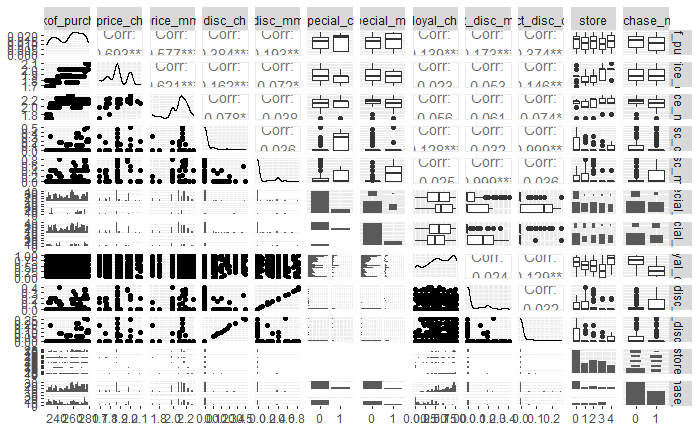

## Thoughts

Some components do still have a high correlation i.e. discount for ch and mm. Variables which look as if they will be used in the model:

- loyal_ch
- price_mm
- store